# Introduction to data science - Ch7

# From problem to model building

In this section we will cover : - mapping problems to machine learning models - evaluate the quality and effectiveness of models

The first section will provide an overview of the basic problems that can be solved with data science and how to choose the right type of model for the given problem.

We will then evaluate if a model is performing well enough for the needs of the project. It takes great experience and insigt to know how to translate problem (question) to a usable model :

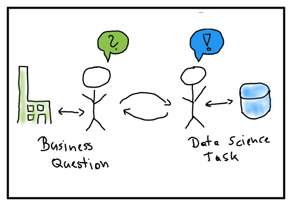

# Data science questions

There are common questions that are common to seek answers in data science :

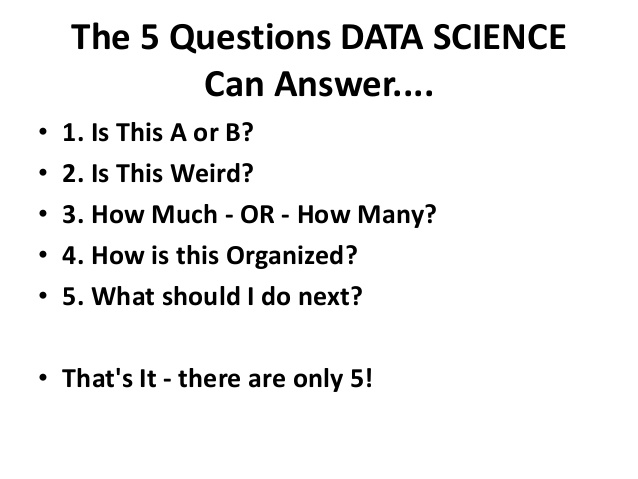

You can find more info about common data science question [here](https://docs.microsoft.com/bs-cyrl-ba/Azure/machine-learning/studio/data-science-for-beginners-the-5-questions-data-science-answers). # Business problems

Common world business problems that are usually solved with data science :

- Predict which products a customer might buy
- Detect fraud
- Calculate price elasticity
- Product search engine
- Customer segmentation
- Optimizing how much to spend in AdWords
- Evaluating marketing campaigns
- Organizing new products into a product catalog # Main types of models ## Classification

Classification can be done betweek two categories (binomial) or multiple categories. One evident business problem solved by classification is *Product Categorization*

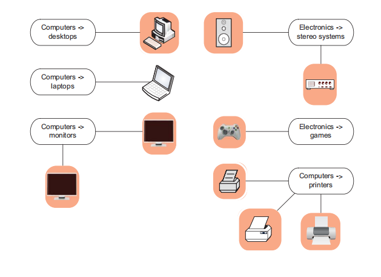

Some of the most popular classification methods are :

### naive Bayes

- good with multi-level input categories
- product categorization
- text classification

### Decision trees

- if-then situations
- redundent and correlated inputs
- easier to interpret

### Logistic regression

- class probabilities
- probability of fraud
- probability sensitivity analysis

### Support vector machines

- many input variables
- input correlated with outcome
- less asumptions about input distributions

## logistic regression

- predicts 0 or 1
- predicting probabilities of categories -> scoring

[figure not shown]

## Clustering (unsupervised)

Unsupervised learning : Custering can be used when no outcomes are known (missing or non-existing yet). It can help discovering patterns and relationships in the data. Some common clustering methods are :

### K-means clustering (unknown groups)

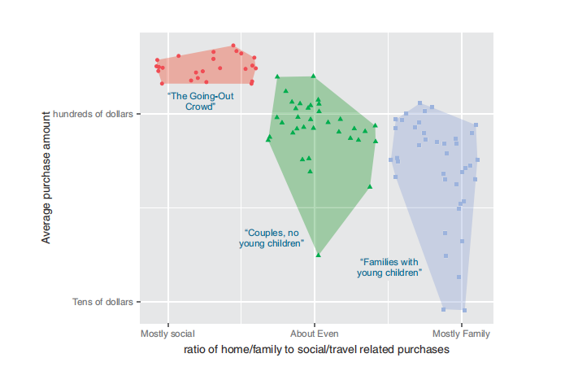

### Association rules (Apriori)

- Identify strong rules
- Ex: Predict products that are usually bought together
- Useful for recommendations

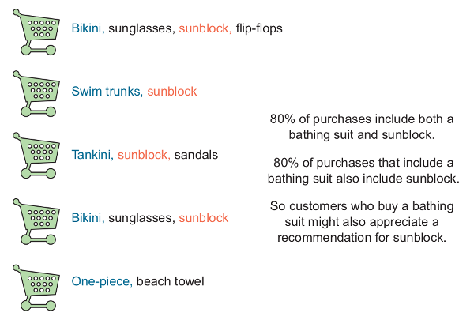

### Nearest neighbor

- Another method applicable for recommendations
- Observe the behavior of others that are most similar (nearest) to the subject under study
- Make a prediction for the subject

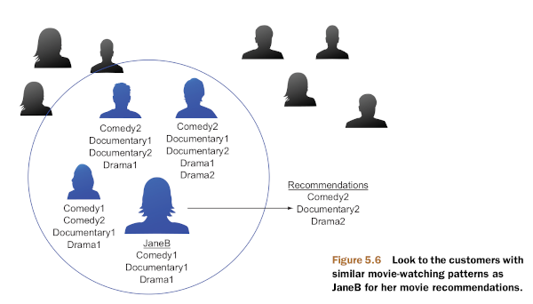

## Exercise 6.1

Find which data science models could be applied to the business problems given in column *Example Tasks* :

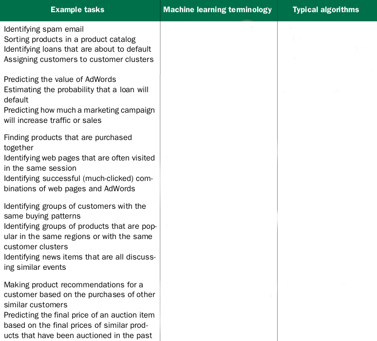